# Probability Distribution of a Sum of Independent Random Variables

Group #1

Harry Lazaridis, harrylaz@kth.se

San Kaneskan, sanmo@kth.se

# Summary of the results and findings

This project investigated the probability of winning a dice game involving five fair dice with 4, 6, 8, 12 and 20 sides. A player won when the total sum was at most 10 or at least 45.

Discrete convolution was used to calculate the exact probability distribution of the sum. The distribution was symmetric, and the probabilities of obtaining a sum below or equal to 10 and above or equal to 45 were both approximately 0.00534. This gave an exact winning probability of 0.01068, or approximately 1.068%.

Monte Carlo simulation was then used to estimate the same probability. The results showed large variations when a small number of trials was used. As the number of trials increased, the simulated probability generally became more stable and moved closer to the exact result.

The relative-error experiment also showed that accuracy improved with more trials. Only 18% of the simulations with 1,000 trials had an error below 10%, compared with 94% using 50,000 trials. With 100,000 trials, all 50 repeated simulations had an error below 10%. Based on these experiments, 100,000 trials was selected as a suitable number for producing a reliable estimate.

# Description of the methodology

The game was modelled using five different dice with 4, 6, 8, 12 and 20 sides. For an (n)-sided die, the possible outcomes were the integers from 1 to (n). Since all dice were fair, every outcome had the probability (1/n).

The total sum of the five dice was represented by **S**. The smallest possible sum was 5 and the largest possible sum was 50. A trial was counted as a win if **S ≤ 10** or **S ≥ 45**.

## Task 1 and 2

Tasks 1 and 2 were done using discrete convolution to calculate the probability distribution of **S**, which is the sum of all five dice. The probability function of each dice was first represented by an array containing **n** values equal to 1/**n**. The probability of each possible sum was then found by multiplying the probabilities of all pairs of outcomes that produced that sum and adding the results together.

## Task 3

Task 3 was done using a Monte Carlo simulation to estimate the probability of winning. During each trial, all five dice were simulated by generating a random integer from 1 to **n**, including both limits, for each die. The results from the five dice were then added together to calculate **S**.

If **S ≤ 10** or **S ≥ 45**, the trial was counted as a win. This process was repeated 1,000 times, and the simulated probability was calculated by dividing the number of winning trials by the total number of trials.

## Task 4

For Task 4, the Monte Carlo simulation was performed using different numbers of trials, starting from 10 and increasing up to 100,000. The simulated probability of winning was calculated once for each number of trials and the results were stored in a table.

The results were then displayed in a figure to show how the simulated probability changed as the number of trials increased. A logarithmic scale was used for the number of trials because the tested values covered a large range. The exact probability from Task 2 was added as a horizontal line, which made it possible to compare the simulated results with the exact result.

## Task 5

For Task 5, the relative error between the simulated probability and the exact probability from Task 2 was calculated. The relative error was found by taking the absolute difference between the two probabilities and dividing it by the exact probability.

The numbers of trials tested were 1,000, 5,000, 10,000, 50,000 and 100,000. Each number of trials was tested 50 times because the result of a Monte Carlo simulation can change each time it is performed. For each number of trials, the program counted how many of the 50 simulations had a relative error below 10%.

The number of successful simulations was then divided by 50 to calculate the proportion of results with an error below 10%. These proportions were stored in a table and used to observe how many trials were needed to produce a sufficiently accurate result.

A **Weibull distribution** was not used because the dice followed discrete uniform distributions. A **Markov chain** was also unnecessary because every dice throw and Monte Carlo trial was independent and did not depend on any previous result.

# Mathematical formulas and equations

Relevant formulas and equations

## Task 2

P(Win) = P(S ≤ 10) + P(S ≥ 45)

## Task 3

P(simulation) = Number of Wins / Number of Trials

## Task 5

Relative Error = |P(simulation) - P(exact)| / P(exact)

# Numerical results

## Task 1

Table 1 presents the probability distribution of **S** for every possible sum from 5 to 50.

| s | P(S = s) |
| --- | --- |
| 5 | 0.00002170 |
| 6 | 0.00010851 |
| 7 | 0.00032552 |
| 8 | 0.00075955 |
| 9 | 0.00149740 |
| 10 | 0.00262587 |
| 11 | 0.00421007 |
| 12 | 0.00629340 |
| 13 | 0.00887587 |
| 14 | 0.01191406 |
| 15 | 0.01534288 |
| 16 | 0.01907552 |
| 17 | 0.02300347 |
| 18 | 0.02699653 |
| 19 | 0.03092448 |
| 20 | 0.03465712 |
| 21 | 0.03808594 |
| 22 | 0.04112413 |
| 23 | 0.04370660 |
| 24 | 0.04578993 |
| 25 | 0.04735243 |
| 26 | 0.04839410 |
| 27 | 0.04891493 |
| 28 | 0.04891493 |
| 29 | 0.04839410 |
| 30 | 0.04735243 |
| 31 | 0.04578993 |
| 32 | 0.04370660 |
| 33 | 0.04112413 |
| 34 | 0.03808594 |
| 35 | 0.03465712 |
| 36 | 0.03092448 |
| 37 | 0.02699653 |
| 38 | 0.02300347 |
| 39 | 0.01907552 |
| 40 | 0.01534288 |
| 41 | 0.01191406 |
| 42 | 0.00887587 |
| 43 | 0.00629340 |
| 44 | 0.00421007 |
| 45 | 0.00262587 |
| 46 | 0.00149740 |
| 47 | 0.00075955 |
| 48 | 0.00032552 |
| 49 | 0.00010851 |
| 50 | 0.00002170 |

*Table 1: Probability distribution of the sum of the five dice.*

## Task 2

| Event | Probability |
| --- | --- |
| S ≤ 10 | 0.00534 |
| S ≥ 45 | 0.00534 |
| Win | 0.01068 |

The exact probability of winning was approximately **1.068%**.

## Task 3

| Method | Number of trials | Probability of winning |
| --- | --- | --- |
| Monte Carlo simulation | 1,000 | 0.01100 |
| Discrete convolution | Exact | 0.01068 |

## Task 4

| number_of_trials | results |
| --- | --- |
| 10 | 0.000000 |
| 50 | 0.020000 |
| 100 | 0.000000 |
| 500 | 0.008000 |
| 1000 | 0.010000 |
| 5000 | 0.010000 |
| 10000 | 0.008900 |
| 50000 | 0.011760 |
| 100000 | 0.011040 |

[figure not shown]

*Figure 1: The estimated winning probability for different numbers of trials. The dashed horizontal line represents the exact probability.*

## Task 5

Each number of trials was tested 50 times.

| Number of trials | Proportion below 10% error |
| --- | --- |
| 1,000 | 0.18 |
| 5,000 | 0.58 |
| 10,000 | 0.72 |
| 50,000 | 0.94 |
| 100,000 | 1.00 |

# Analysis and discussion

## Tasks 1 and 2

The discrete convolution produced a probability distribution for every possible value of S from 5 to 50. The probabilities added up to 1, which showed that all possible results were included in the distribution. The distribution was symmetric around the middle values 27 and 28. These values had the highest probabilities, while sums close to 5 and 50 had much lower probabilities.

The symmetry can be explained by the fact that all five dice were fair. For every combination that produced a low sum, there was a corresponding combination that produced an equally likely high sum. This can also be seen from the results because P(S ≤ 10) and P(S ≥ 45) were both approximately 0.00534.

The exact probability of winning was calculated as

P(Win)=0.00534+0.00534=0.01068.

This corresponds to approximately 1.068%. The probability of winning was therefore low, which means that a player would win approximately once every 94 games on average. This does not mean that a win will occur exactly every 94 games, since the results of individual games are random.

## Task 3

The Monte Carlo simulation with 1,000 trials produced a winning probability of 0.01100 or 1.1%. This was compared with the exact probability of 0.01068 or 1.068% obtained using discrete convolution.

The simulated result was slightly higher than the exact result. The difference occurred because the Monte Carlo method is based on random trials. Since the winning probability is only around 1%, 1,000 trials produce a relatively small number of wins. A difference of only a few wins can therefore noticeably change the estimated probability.

The simulation result also changes when the program is run again because no fixed random seed was used. It is therefore not expected that the simulated probability will be exactly equal to the convolution result.

## Task 4

As the number of trials increased, the simulated probability generally became more stable and moved closer to the exact probability. The estimates from 50,000 and 100,000 trials were closer to the horizontal line representing the exact result than most of the estimates from the smaller trial counts.

However, the simulated probability did not necessarily become closer to the exact result after every increase in the number of trials. Random variation can cause one smaller simulation to be more accurate than a larger simulation by chance. The overall pattern in the figure was more important, larger numbers of trials generally produced more stable and reliable estimates.

## Task 5

For Task 5, each tested number of trials was repeated 50 times. The results showed that the proportion of simulations with a relative error below 10% increased as the number of trials increased.

With 1,000 trials, only 0.18, or 18%, of the simulations had a relative error below 10%. The proportion increased to 0.58 for 5,000 trials and 0.72 for 10,000 trials. With 50,000 trials, the proportion reached 0.94, meaning that 47 out of 50 simulations met the requirement. Finally, 100,000 trials produced a proportion of 1.00, meaning that all 50 simulations had a relative error below 10%.

Based on these experiments, 100,000 trials was selected as the required number because it was the first tested value where every repeated simulation had a relative error below 10%. The result does not guarantee that every future simulation with 100,000 trials will meet the requirement, since Monte Carlo simulations are random. However, it was the most reliable value among the tested numbers of trials.

# Code

## Imports

```python
import numpy as np
from numpy import random
import pandas as pd
import matplotlib.pyplot as plt
```

## Task 1 & 2 - Discrete convolution

```python
#Task1
#Number of sides on the five dices
faces = np.array([4, 6, 8, 12, 20])

#Create the probabilty function for the dices based on (n)
def p(n):
    return np.ones(n) / n

#Start the probability function of the first dice of the array, the four sides dice
pf = p(faces[0])
for n in faces[1:]: #Comvbine the probability distributions for the rest of the dices
    pf = np.convolve(pf, p(n))

#Create the possible sums from 5 to50
s_values = np.arange(5, 5 + len(pf))
```

```python
table = pd.DataFrame({"s": s_values, "P(S = s)": pf})
table
print(table.to_markdown(index=False, floatfmt=".8f"))
```

```
|           s |   P(S = s) |
|------------:|-----------:|
|  5.00000000 | 0.00002170 |
|  6.00000000 | 0.00010851 |
|  7.00000000 | 0.00032552 |
|  8.00000000 | 0.00075955 |
|  9.00000000 | 0.00149740 |
| 10.00000000 | 0.00262587 |
| 11.00000000 | 0.00421007 |
| 12.00000000 | 0.00629340 |
| 13.00000000 | 0.00887587 |
| 14.00000000 | 0.01191406 |
| 15.00000000 | 0.01534288 |
| 16.00000000 | 0.01907552 |
| 17.00000000 | 0.02300347 |
| 18.00000000 | 0.02699653 |
| 19.00000000 | 0.03092448 |
| 20.00000000 | 0.03465712 |
| 21.00000000 | 0.03808594 |
| 22.00000000 | 0.04112413 |
| 23.00000000 | 0.04370660 |
| 24.00000000 | 0.04578993 |
| 25.00000000 | 0.04735243 |
| 26.00000000 | 0.04839410 |
| 27.00000000 | 0.04891493 |
| 28.00000000 | 0.04891493 |
| 29.00000000 | 0.04839410 |
| 30.00000000 | 0.04735243 |
| 31.00000000 | 0.04578993 |
| 32.00000000 | 0.04370660 |
| 33.00000000 | 0.04112413 |
| 34.00000000 | 0.03808594 |
| 35.00000000 | 0.03465712 |
| 36.00000000 | 0.03092448 |
| 37.00000000 | 0.02699653 |
| 38.00000000 | 0.02300347 |
| 39.00000000 | 0.01907552 |
| 40.00000000 | 0.01534288 |
| 41.00000000 | 0.01191406 |
| 42.00000000 | 0.00887587 |
| 43.00000000 | 0.00629340 |
| 44.00000000 | 0.00421007 |
| 45.00000000 | 0.00262587 |
| 46.00000000 | 0.00149740 |
| 47.00000000 | 0.00075955 |
| 48.00000000 | 0.00032552 |
| 49.00000000 | 0.00010851 |
| 50.00000000 | 0.00002170 |
```

```python
#Task2
#Add probability where the sum is at most 10
p_low = pf[(s_values <= 10)].sum()
p_high = pf[(s_values >= 45)].sum() #At least 45
p_win = p_low + p_high #Probabilty of winning

#Print the exact probabilities
print(f"P(S <= 10) = {p_low:.5f}")
print(f"P(S >= 45) = {p_high:.5f}")
print(f"P(Win) = {p_win:.5f}")
```

```
P(S <= 10) = 0.00534
P(S >= 45) = 0.00534
P(Win) = 0.01068
```

## Task 3, 4 & 5

```python
#Task3
#Estimation of probabilit of winning using monte carlo simulation
def simulation_probability_of_win(n_trials):
    win = 0
    for _ in range(n_trials): #Repeat the game for x amount of trials
        S = 0
        for n in faces: #simulate the throwing of all dices
            S += random.randint(1, n + 1) #Generates the results
        if S <= 10 or S >= 45:
            win += 1
    return win / n_trials

p_win_1000 = simulation_probability_of_win(1000) #Runs the simulation 1000 times

print(f"Monte Carlo simulation with 1000 trials: {p_win_1000:.5f}") #Comparison
print(f"Discrete convolultion: {p_win:.5f}")
```

```
Monte Carlo simulation with 1000 trials: 0.01100
Discrete convolultion: 0.01068
```

```python
#Task4
#Simulation of the monte carlo using different amount of runs/trials
trials_amount = [10, 50, 100, 500, 1000, 5000, 10000, 50000, 100000]

#One simulated probability for each number of trials
sim = [simulation_probability_of_win(n) for n in trials_amount]

results = pd.DataFrame({
    "number_of_trials": trials_amount,
    "results": sim
})

results
```

|  | number_of_trials | results |
| --- | --- | --- |
| 0 | 10 | 0.00000 |
| 1 | 50 | 0.02000 |
| 2 | 100 | 0.00000 |
| 3 | 500 | 0.00800 |
| 4 | 1000 | 0.01000 |
| 5 | 5000 | 0.01000 |
| 6 | 10000 | 0.00890 |
| 7 | 50000 | 0.01176 |
| 8 | 100000 | 0.01104 |

```python
print(results.to_string(index=False))
```

```
 number_of_trials  results
               10  0.00000
               50  0.02000
              100  0.00000
              500  0.00800
             1000  0.01000
             5000  0.01000
            10000  0.00890
            50000  0.01176
           100000  0.01104
```

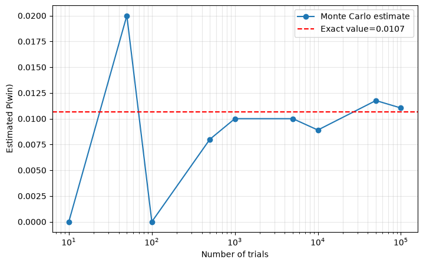

```python
#Plotting for figure for task4
plt.savefig(
    "task4_simulation.png",
    dpi=300,
    bbox_inches="tight"
)
plt.figure(figsize=(8, 5))
plt.semilogx(trials_amount, sim, "o-", label="Monte Carlo estimate")
plt.axhline(p_win, color="red", linestyle="--", label=f"Exact value={p_win:.4f}")
plt.xlabel("Number of trials")
plt.ylabel("Estimated P(win)")
plt.legend()
plt.grid(alpha=0.3, which="both")
plt.savefig(
    "task4_simulation.png",
    dpi=300,
    bbox_inches="tight"
)

plt.show()
```

```python
#Task 5
#How often the relative error is below 10%
def successes(n, reps=50):
    success = 0
    for _ in range(reps): #Repeats the simulation 50 times
        P = simulation_probability_of_win(n) #simulated probability
        relative_error = abs(P - p_win) / p_win #Formula for relative error
        if relative_error < 0.10: #If below 10% then add to success counter
            success += 1
    return success / reps

#different numbers of trials
test_trials = [1000, 5000, 10000, 50000, 100000]
success_rates = [successes(n) for n in test_trials]

# Display the results
task5_results = pd.DataFrame({
    "Number of trials": test_trials,
    "Proportion below 10% error": success_rates
})

print(task5_results.to_string(index=False))
```

```
 Number of trials  Proportion below 10% error
             1000                        0.18
             5000                        0.58
            10000                        0.72
            50000                        0.94
           100000                        1.00
```